# A very brief introduction to mediation analysis

Guido Biele

5/11/2021

This document contains a brief summary of what I consider to be important points of Tyler J. VanderWeele’s summary of his own work in “Mediation Analysis: A Practitioner’s Guide” (2016, Annual Review of Public Health)

# 1 Effects and associations

It is not uncommon that the awareness about the difficulty of drawing causal inferences from observational data leads researchers to avoid clear causal language like “the exposure causes the outcome” and instead to use less explicit language like “is associated with” or “is a risk factor for”, all the while more or less subtly still treating the results of an analysis as if it could inform the reader about some causal relationship.

This ambiguous (and to be clear, a bit dishonest) approach is not possible when researching mediation effects, which are clearly defined in causal terms.

> In mediation, we consider an intermediate variable, called the mediator, that helps explain how or why an independent variable influences an outcome.

(Source: Gunzler et al, 2013).

# 2 Total, direct and indirect effects

To understand mediation analysis, it is useful to first describe how the total effect of an exposure on an outcome can be de-composed into direct and indirect effects.

We can draw a simple directed acyclic graph (DAG) that contains direct and indirect effects.

Before we do this, here is some basic notation:

We have

- $A$, the exposure ($a$ is a realization of $A$)
- $M$, the mediator
- $Y$, the outcome of interest

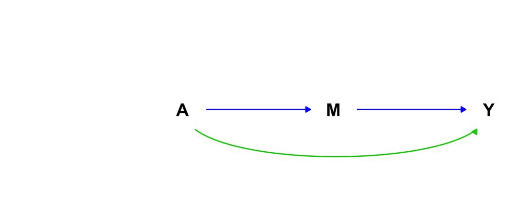

Figure 2.1: The total effect of $A$ on $Y$ is the sum of the direct effect ($A \rightarrow Y$, in green) and the indirect effects ($A \rightarrow M \rightarrow Y$, in blue). Mediation analysis is generally interested in measuring how much of the effect of $A$ goes through or is mediated by a variable $M$.

In short, `total_effect = direct_effect + indirect_effect`.

# 3 Counterfactual definitions of direct and indirect effects

The **controlled direct effect** measures the effect of $A$ on $Y$ when $M$ is fixed to a specific value and is expressed as

$$Y_{a_0m}-Y_{a_1m},$$

where $Y{a_0}$ is the outcome when the exposure is set to $0$. That is, we are calculating the difference in outcome values when $A$ has the values $a_0$ or $a_1$, while fixing the mediator to a value $m$.

For example, if we want to show how much of the effect of parental divorce on child mental health problems is *not* mediated by parental fighting, we would compare children of divorced and non-divorced parents at a fixed level of parental fighting. This level could e.g. be the average level of fighting across all parents.

In comparison, the **natural direct effect**

> … fixes the value of the mediator to the "level which it naturally would have been under—for example, the absence of exposure.

such that–continuing the above example– we would calculate the effect of divorce while setting fighting level to “low”.
$$Y_{a_0Ma_0}-Y_{a_1Ma_0}.$$

The important thing here is that $M$ is fix whereas $A$ varies when we estimate the direct effect of $A$. In linear models, the natural and controlled direct effects have the same value.

Lastly, the **natural indirect effect** compares the outcome at two different values of $M$ while $A$ is fixed:
$$Y_{aMa_1}-Y_{aMa_0},$$

This highlights why these definitions are counterfactual: They involve comparison of quantities that we (typically) do not oberve: For instance. One specific way to calculate the indirect effect would be $Y_{a_0Ma_1}-Y_{a_0Ma_0}$, were $Y_{a_0Ma_1}$ is the outcome assuming that the exposure has the value 0, and the mediator has the value it (usually) has when the exposure is 1. This expression is a counterfactual, because we are estimating “what would have been” because we (typically) do not observe such people.

To come back to our example, we could calculate the difference in predicted outcomes between these two situations: Divorced parents who fight a lot and divorced parents parents who do not fight. Alternatively, we could also calculate the difference between *non*-divorced parents who fight a lot and *non*-divorced parents parents who do not fight. The key is that we keep the realization of the exposure $A$ fixed and let the realization of $M$ vary.

Now, what has all this to do with mediation? *We say an effect is mediated when the indirect effect is non-zero*.

One important reason for understanding the calculation of direct and indirect effects in basic terms is that it allows one to think about how one could calculate them in arbitrary analysis situations. That is, also in situations where direct or indirect effects cannot easily be gleaned from regression model coefficients. The goal of mediation analysis methods we are discussing next is to estimate as just defined.

# 4 Traditional methods to calculate indirect and direct effects

Calculating direct and indirect effects is often/typically done based on regression models.

## 4.1 The Difference Method

The difference method is based on estimating two regression models, one which does and one which does not include the mediator.

The first estimates the expected value of the outcome $Y$ given the exposure $a$ and confounders $c$:

$$E[Y|a,c] = \phi_0 + \phi_1a + \phi_3c,$$
where $\phi$ are regression weights. The important thing here is that this regression does not use $M$ as a predictor. Therefor the total effect of the expsore is simply the regression weight for the model without the mediator:

$$TE = \phi_1$$

The second regression includes the mediator:

$$E[Y|a,m,c] = \theta_0 + \theta_1a + \theta_2m + \theta_3c,$$

The logic of the difference method is that if the effect of the exposure is considerably smaller in the second regression, which also includes the mediator variable, then some of the effect of $A$ has to got through $M$. In this framework, one can calculate the indirect effect, $IE$, by subtracting the weight for the exposure in the model with the mediator from the weight for the exposure in the model without the mediator:

$$IE_{diff} = \phi_1 - \theta_1$$

Correspondingly, the direct effect is the weight of the exposure in the model that also includes the mediator:

$$DE = \theta_1.$$

Now that’a all fine, but you are maybe wondering **HOW DO I KNOW IF THE INDIRECT EFFEFT IS STATISTICALLY SIGNIFICANT???**. One way to address this is to do model comparison, i.e. to check if the model that does incluse the mediator fits the data statistically significant better than the model without mediators. This could be done with a likelihood ratio tests, AIC, BIC, though none of these methods is perfect and with enough data, the model with more predictors will always fit the data better.

## 4.2 The Product Method

Psychologists who have worked with SEMs will typically be more familiar with the product method.

Intuitively, this methods calculates the indirect effect by asking *How much of the outcome can I explain when I know the effect of the exposure on the mediator and of the mediator on the outcome?* While total effects in SEMs are calculated by adding the multiplied coefficients along all direct and indirect paths from the predictor to the outcome, the product method described here still involves 2 regressions:

One regression examines the causal effect of the exposure on the mediator.

$$E[M|a,c] = \beta_0 + \beta_1a + \beta_3c,$$

The second regression investigates the effect of the mediator on the outcome in presence of a direct effect of the exposure. That is, this is again the 2nd regression model described for the difference method.

$$E[Y|a,m,c] = \theta_0 + \theta_1a + \theta_2m + \theta_3c,$$

Following the intuition described above, the indirect effect is the calculated as

$$IE_{prod} = \theta_2\beta_1$$

That is, there is only a mediation effect if there is a (causal) effect of $A \rightarrow M$ and of $M \rightarrow Y$.

As one would hope and expect, the product method and the difference method produce the same results. This is, however, only true for linear regression models and not for logistic regression models. Indeed, simply applying these methods to outputs from logistic regressions or any regression that involves non-linear link function will to lead incorrect results.

# 5 Assumptions about the lack of confounding

Using a linear model is one condition for a valid use of the difference or product method described above. In addition, mediation analyses makes several assumptions about the lack of unobserved confounding variables. The reason for there being *several* assumptions is that calculating direct and indirect effects involves estimating different causal effects, and the estimation of each causal effect requires a new set of (similar) assumptions.

Before going through these assumptions, lets look at a DAG that depicts the data-generating process under which we can estimate mediation effects.

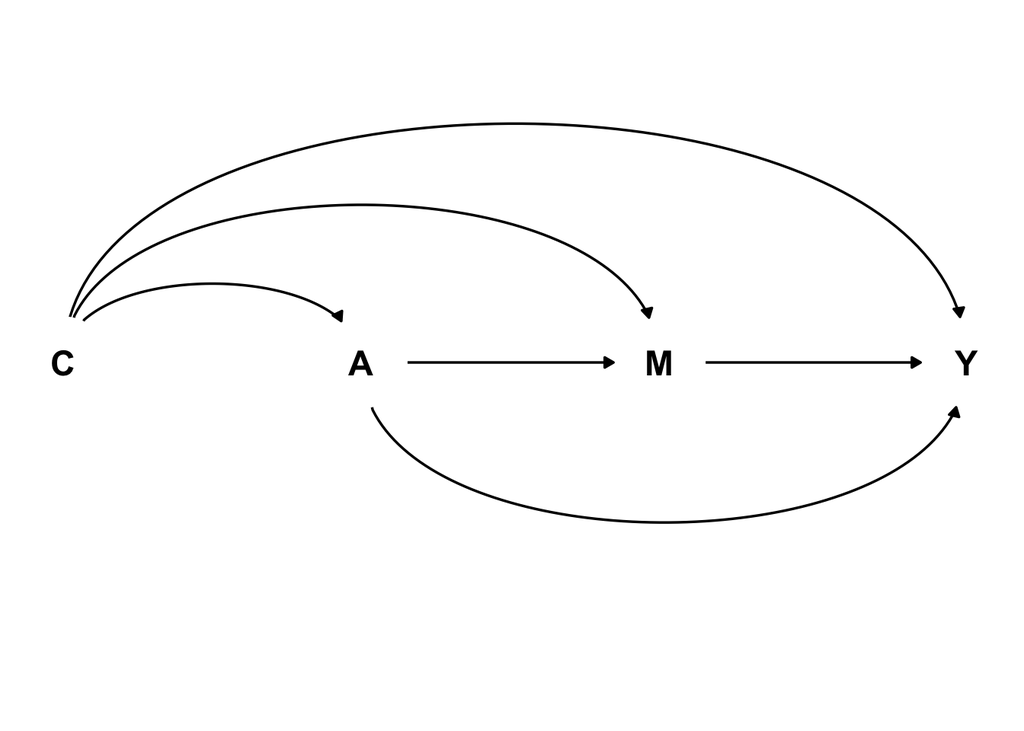

Figure 5.1: A directed acyclic graph (DAG) describing a scenario in which direct and indirect effects can be calculated. The most important paths in this DAG are the absent paths from common unobserved causes.

## 5.1 No exposure - outcome confounding

The first assumption is the basic assumption made for any analyses that estimates a causal effect from observational data: There must not be unobserved variables $U$ that cause both the the exposure $A$ and the outcome $Y$.

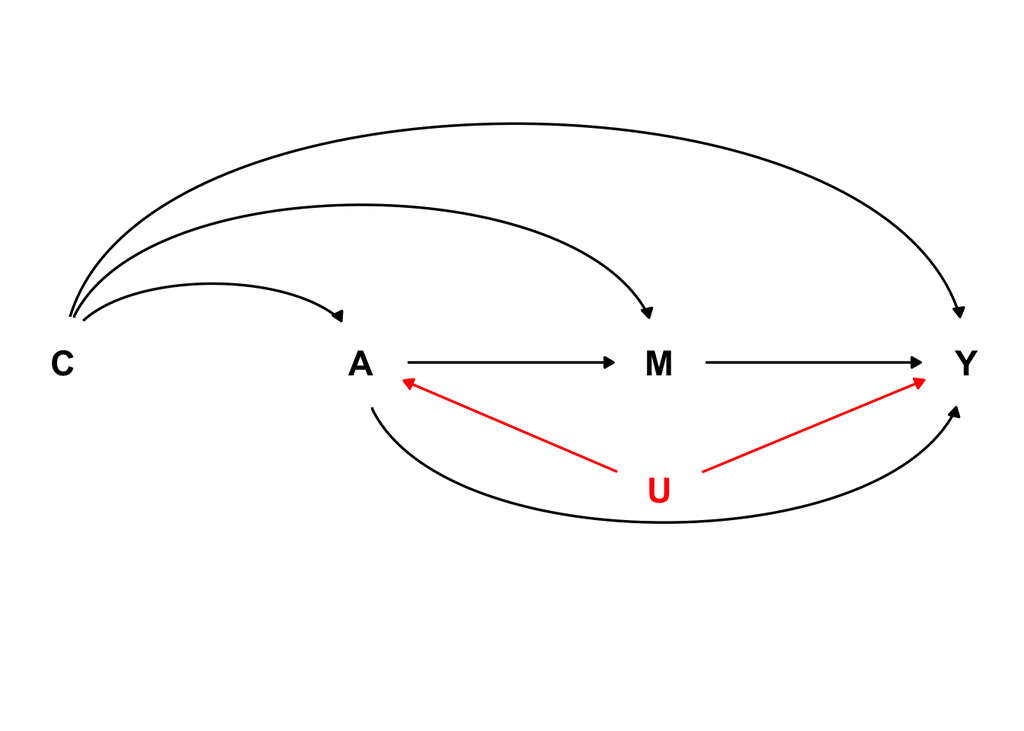

Figure 5.2: A DAG with an unobserved confounder between exposure and outcome.

Coming back to our example: We must assume that there are no unobserved variables that cause divorce and child mental health problems. Such variables could include parental mental health or temperament, parental education, or genetic vulnerabilities.

## 5.2 No mediator - outcome confounding

The next causal effect we are interest in is the effect of the mediator on the outcome, which we only can estimate if there is no unobserved confounding for this relationship:

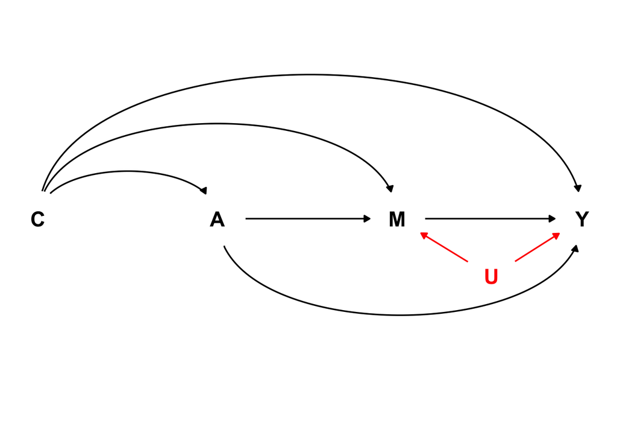

Figure 5.3: A DAG with an unobserved confounder between mediator and outcome.

Coming again back to our example, we would assume that we have measured things like parental temperament, prior mental health problems of the child and that there are no other common causes of fighting between parents and child mental health that were not measured.

## 5.3 No exposure - mediator confounding

To complete our chain of unbiased causal effects, we also need to assume that there are no unmeasured common causes of exposure and mediator:

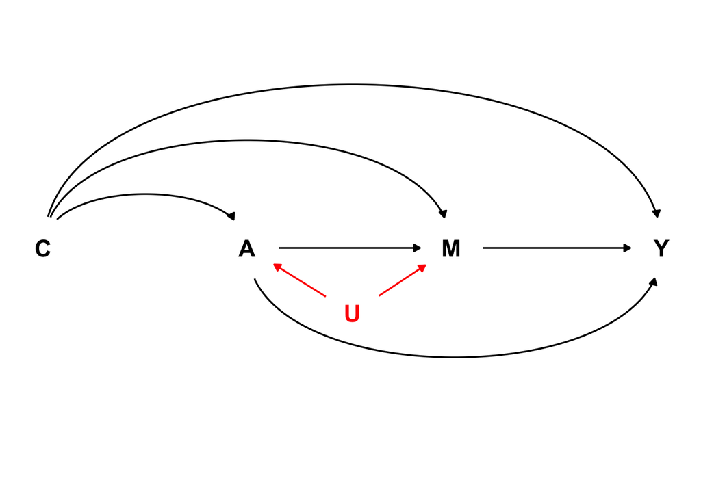

Figure 5.4: A DAG with an unobserved confounder between exposure and mediator.

So we would like to have measured that, e.g., parents have compatible parenting styles and expectations towards the child, that parents do not have unknown mental health problems that can be causes of divorce and child mental health, etc.

The psychological literature on estimating mediation effects is in theory aware of the importance of assumption of no unobserved confounding, as e.g. this quote shows (source: http://davidakenny.net/cm/mediate.html).

> Omitted Variables: In this case, there is a variable that causes both variables in the equation. These variables are called confounders in some literatures and the assumption can be stated more formally and generally, see below. For example, there is a variable that causes both the mediator and the outcome. This is the most likely source of specification error and is difficult to find solutions to circumvent it. [Unfortunately, this key assumption is not directly discussed in Baron and Kenny (1986), but is discussed in Judd and Kenny (1981).] Although there has been some work on the omitted variable problem, the only complete solution is to specify and measure such variables and control for their effects.

However, this seems not always to be discussed before anything else, which I think is the right thing to do.

## 5.4 Measured confounders must not be mediators

Given that all assumptions so far were about absence of unobserved confodunders, one might want to conclude that mediation analyses are generally safe when there are no unobserved confounders. This is, however, not the case. It is possible that we have observed confounders, which are however also mediators between the exposure and the outcome. In this case, we cannot simply include the confounder which is also a mediator.

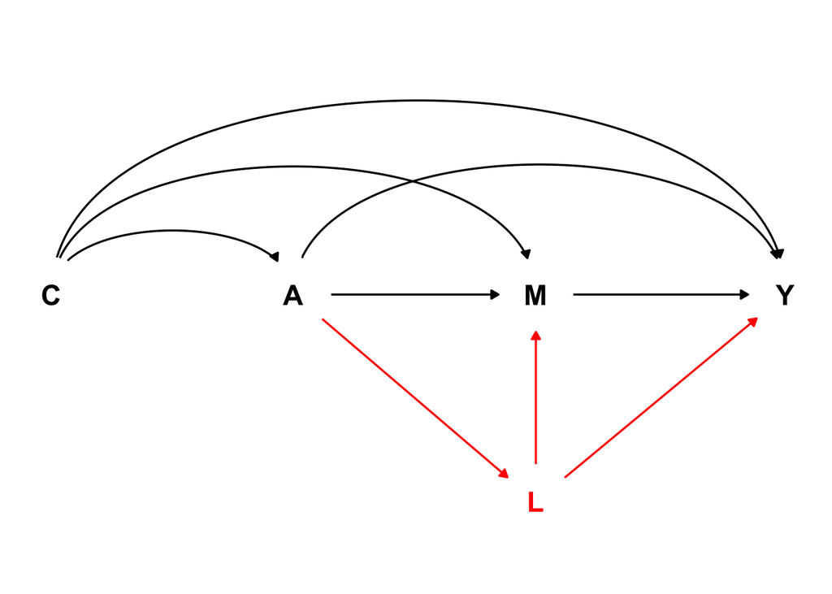

Figure 5.5: A DAG where a mesaured confounder (L) is also a mediator.

Such a situation makes a straight forward estimation of a mediation effect difficult: On the one hand, we want that the coefficient $\theta_1$ captures the effect of $A$ after we have accounted for $M$. If we want to accurately account for the effect of $M$ we need also to adjust for $L$. However, if we adjudt for $L$, $\theta_1$ captures less than the total effect ($TE$) of $A$ after we have accounted for $M$, because we have also accounted for the effect of $A$ that goes through $L$. If we would adjust for for $M$ and $L$ when estimating the coefficient $\theta_1$, we would see an inflated effect indirect effect of $M$ because the coefficient for the total effect of the exposure in the model with two adjustments would be too small.

$$\begin{aligned}
IE_{diff} = \phi_1 - \theta_1 \\
E[Y|a,m,c] = \theta_0 + \theta_1a + \theta_2m + \theta_3c \\
E[Y|a,m,l,c] = \eta_0 + \eta_1a + \eta_2m + \eta_3l + \eta_4c \\
\theta_1a \neq \eta_1a
\end{aligned}$$

To come back to our running example again: One could hypothesize the divorce leads to a shrinking social-support network, which can be cause for more fighting between parents (who now have to do more on their own) and reduces the number of people who can help a child who already has some problems like difficulties at school. If this is a plausible scenario, a study that investigates parental fighting as a mediator between divorce and child mental health would have difficulties doing so, even if the social support network were measured.

## 5.5 What can we do about assumptions

The most important implication of the numerous assumptions involved in mediation analyses is that one should carefully think about planned mediation analysis *before data collection*, as it is unlikely that one has measured all relevant or even the most important confounders if a mediation analysis was not planned.

# 6 Other limitations & conditions

- The simple difference or product methods described until here will fail if there are interactions between mediator and exposure (i.e. multiplicative in addition to additive effects), in which case more complicated methods need to be used.
- Reverse causation is much easier to exclude if the exposure is measured before the mediator, and the mediator before the outcome. If variables were measured simulatenously, one would need very strong theoretical reasons to rule out reverse causation.

# 7 Mediation effects in other analyses

## 7.1 Logistic regession

Calculating direct and indirect effects with logistic regression is complicated by the multiplicative (as opposed to additive) effect of covariates, which stops us from using the simplest form of the difference of product method. For outcomes with low probabilities, VanderWeele describes following approximation:

$$\begin{aligned}
logit{P(Y = 1|a,m,c)} = \theta_0 + \theta_1a + \theta_2m + \theta_3c \\
E[M|a,c] = \beta_0 + \beta_1a + \beta_3c \\
OR^{DE} = e^{\theta_1} \\
OR^{IE} = e^{\beta_1\theta_2}
\end{aligned}$$

This is basically the product method which uses the odds ratio as a starting point. As a caveat VanderWeele adds that

> However, if the outcome is not rare (10% is often used as a cutoff), then the product method and the difference method can and do diverge, and, in fact, neither of these approaches nor the expressions given above are valid for the direct and indirect effects.

Hence, the log-binomial instead of the logistic model is recommended.

## 7.2 Structural equation models (SEM)

- no unobserved common causes of exposure and outcome,
- no unobserved common causes of exposure and mediator,
- no unobserved common causes of mediator and outcome and
- common causes of mediator and outcome are not themselves a mediator between exposure and outcome.

One advantage of SEMs is that they are typically estimated in software that also visualizes the model, which facilitates thinking about how realistic these assumptions are.

# 8 Summary

- Mediation analysis is firmly located in the field of causal analysis. Therefore valid inferences require strong assumptions.
- Mediation analysis builds on estimating 3 causal effects $exposure \rightarrow outcome$, $exposure \rightarrow mediator$, $mediator \rightarrow outcome$, and for each we must verify absence of unobserved confounders and/or do sensitivity tests. In addition, we must exclude the possibility that measured confounders are themselves mediators.
- Unfortunately, we have so far only scratched the surface of biased estimation of causal effects, as other types of bias (self selection into the study, loss to follow up, collider bias) can also invalidate each of the effect estimates needed for a mediation analysis

In conclusion: Doing a **valid** mediation analysis is very hard.

In comparison, just doing a mediation analysis is not so hard (still don’t do it).